# Effects of Question Type on E-Learning Performance

Hung Hong, Lane Harrison

December 12, 2019

Analysis of data collected from e-Learning Performance experiment run

References:  
- https://github.com/mjskay/tidybayes  
- @codementum

## Libraries needed

```r
library("jsonlite")
library(RCurl)
library(plyr)
library(tidyverse)
library(sjPlot)
library(sjmisc)
```

## Grab the JSON file from firebase and convert into a list in R

```r
tables <- read_json("https://elearning-20e46.firebaseio.com/.json", simplifyVector = TRUE)
# str(tables)
# tables$Session
```

## Create the `trials` tibble

```r
trials = tibble()
for (quiz in tables$quiz) {
  for (observation in quiz) {
      new_row <- as_tibble(observation)
      trials <- trials %>% bind_rows(new_row)
    # trials <- rbind(trials_df, data.frame(observation))
  }
}

# trials
```

## Create the `surveys` tibble

```r
surveys = tibble()
for (survey in tables$survey) {
    new_row <- as_tibble(survey)
    surveys <- surveys %>% bind_rows(new_row)
}

# surveys
```

## Clean the data to make later function calls easier

### Create `condition` column from `quiz` (to easily filter by condition)

```r
trials$condition <- NA
for (i in seq_along(trials$quiz)) {
  if (trials$quiz[i] == 1)
    condition <- 'Quiz 1'
  else if (trials$quiz[i] == 2)
    condition <- 'Quiz 2'
  else
    condition <- '???'

  trials$condition[i] <- condition
}
```

# Statistical Analysis of Quiz Results

## Histogram Plots of Quiz 1 Results

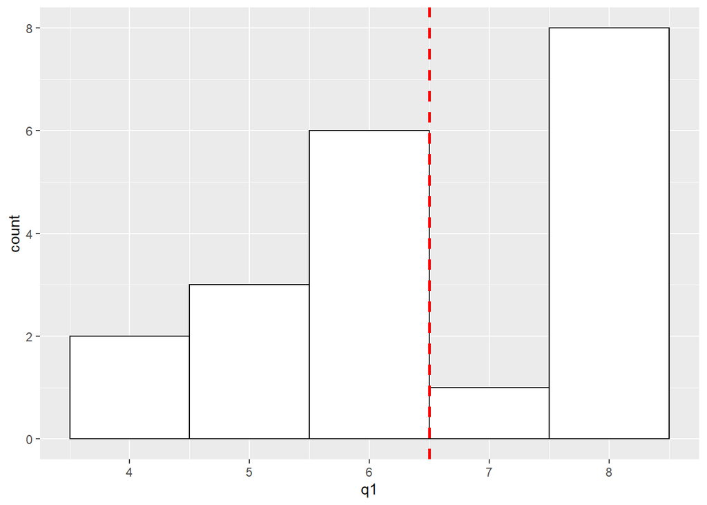

```r
quiz1 <- trials %>%
  filter(condition == "Quiz 1")
quiz1 <- quiz1[,1:4]
ggplot(quiz1, aes(x=q1)) + geom_histogram(binwidth=1, colour="black", fill="white") +
    geom_vline(aes(xintercept=mean(q1, na.rm=T)),   # Ignore NA values for mean
               color="red", linetype="dashed", size=1)
```

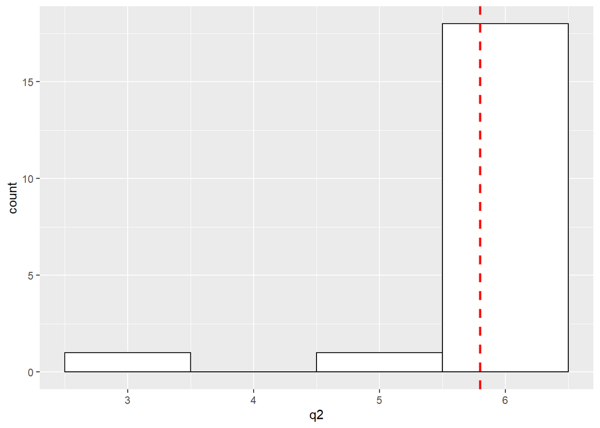

```r
ggplot(quiz1, aes(x=q2)) + geom_histogram(binwidth=1, colour="black", fill="white") +
    geom_vline(aes(xintercept=mean(q2, na.rm=T)),   # Ignore NA values for mean
               color="red", linetype="dashed", size=1)
```

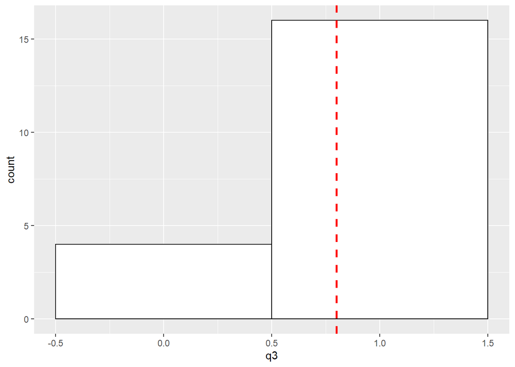

```r
ggplot(quiz1, aes(x=q3)) + geom_histogram(binwidth=1, colour="black", fill="white") +
    geom_vline(aes(xintercept=mean(q3, na.rm=T)),   # Ignore NA values for mean
               color="red", linetype="dashed", size=1)
```

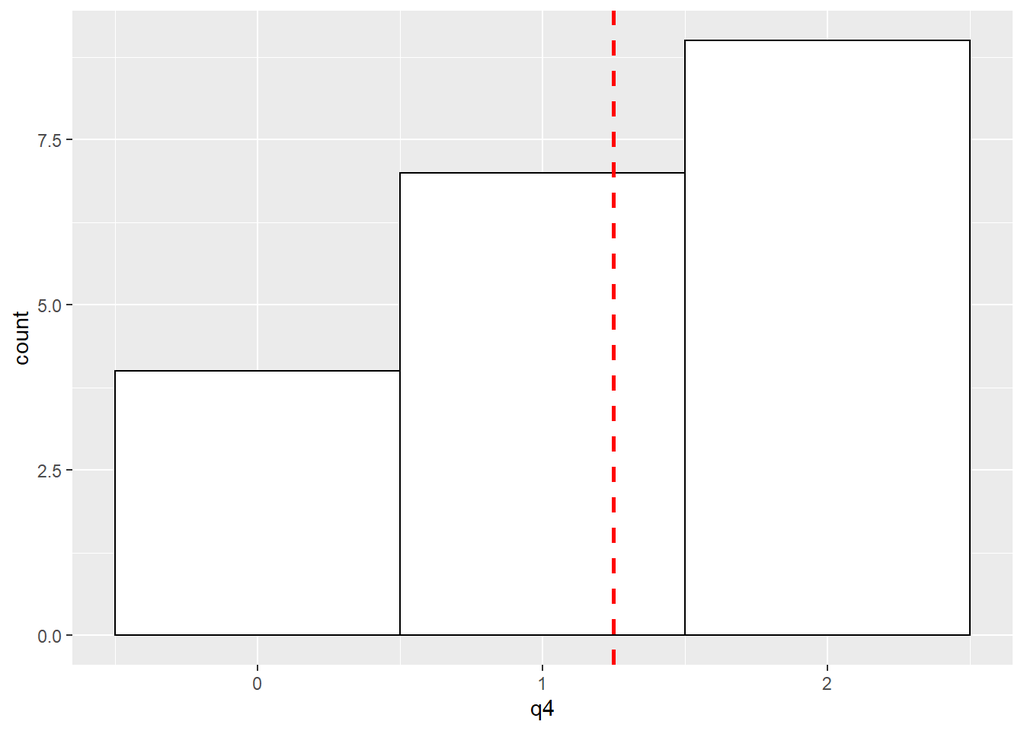

```r
ggplot(quiz1, aes(x=q4)) + geom_histogram(binwidth=1, colour="black", fill="white") +
    geom_vline(aes(xintercept=mean(q4, na.rm=T)),   # Ignore NA values for mean
               color="red", linetype="dashed", size=1)
```

```r
summary(quiz1)
```

```
##        q1             q2            q3            q4
##  Min.   :4.00   Min.   :3.0   Min.   :0.0   Min.   :0.00
##  1st Qu.:5.75   1st Qu.:6.0   1st Qu.:1.0   1st Qu.:1.00
##  Median :6.00   Median :6.0   Median :1.0   Median :1.00
##  Mean   :6.50   Mean   :5.8   Mean   :0.8   Mean   :1.25
##  3rd Qu.:8.00   3rd Qu.:6.0   3rd Qu.:1.0   3rd Qu.:2.00
##  Max.   :8.00   Max.   :6.0   Max.   :1.0   Max.   :2.00
```

## Histogram Plots of Quiz 2 Results

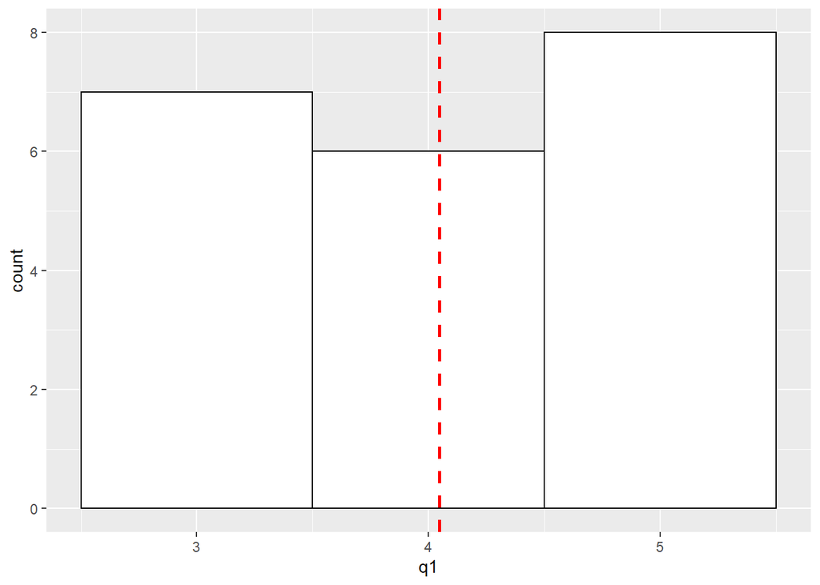

```r
quiz2 <- trials %>%
  filter(condition == "Quiz 2")
quiz2 <- quiz2[,1:4]
ggplot(quiz2, aes(x=q1)) + geom_histogram(binwidth=1, colour="black", fill="white") +
    geom_vline(aes(xintercept=mean(q1, na.rm=T)),   # Ignore NA values for mean
               color="red", linetype="dashed", size=1)
```

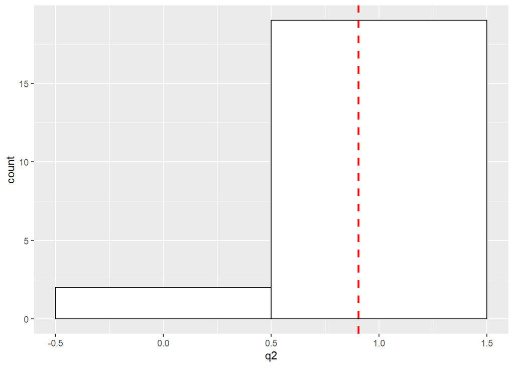

```r
ggplot(quiz2, aes(x=q2)) + geom_histogram(binwidth=1, colour="black", fill="white") +
    geom_vline(aes(xintercept=mean(q2, na.rm=T)),   # Ignore NA values for mean
               color="red", linetype="dashed", size=1)
```

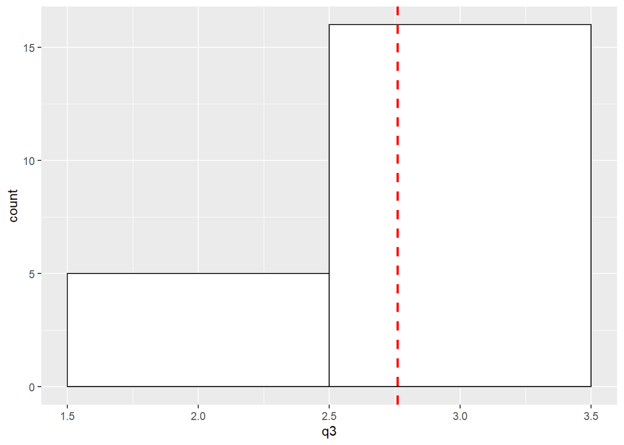

```r
ggplot(quiz2, aes(x=q3)) + geom_histogram(binwidth=1, colour="black", fill="white") +
    geom_vline(aes(xintercept=mean(q3, na.rm=T)),   # Ignore NA values for mean
               color="red", linetype="dashed", size=1)
```

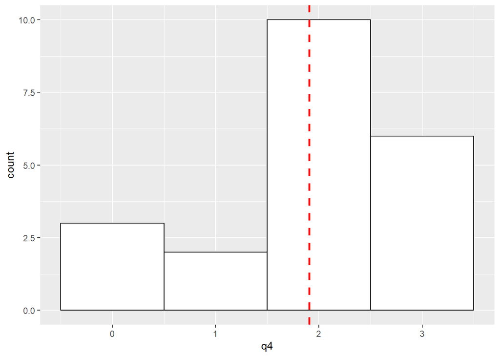

```r
ggplot(quiz2, aes(x=q4)) + geom_histogram(binwidth=1, colour="black", fill="white") +
    geom_vline(aes(xintercept=mean(q4, na.rm=T)),   # Ignore NA values for mean
               color="red", linetype="dashed", size=1)
```

```r
summary(quiz2)
```

```
##        q1              q2               q3              q4
##  Min.   :3.000   Min.   :0.0000   Min.   :2.000   Min.   :0.000
##  1st Qu.:3.000   1st Qu.:1.0000   1st Qu.:3.000   1st Qu.:2.000
##  Median :4.000   Median :1.0000   Median :3.000   Median :2.000
##  Mean   :4.048   Mean   :0.9048   Mean   :2.762   Mean   :1.905
##  3rd Qu.:5.000   3rd Qu.:1.0000   3rd Qu.:3.000   3rd Qu.:3.000
##  Max.   :5.000   Max.   :1.0000   Max.   :3.000   Max.   :3.000
```

Due to the simple nature of the assignments, most participants perform well in the quizzes. It is noticable that participants performed better in questions that contain answer as one of the options, such as Question 2 of Quiz 1 and Question 2, 3 of Quiz 3. We also notice a significantly lower in performance for Question 1, 4 of Quiz 1 and Question 4 of Quiz 4, with the similarity of them being free response question with multiple answer fields.

# Statistical Analysis of Survey Results

## Stack Frequencies Plot of Opnions on E-Learning Platform

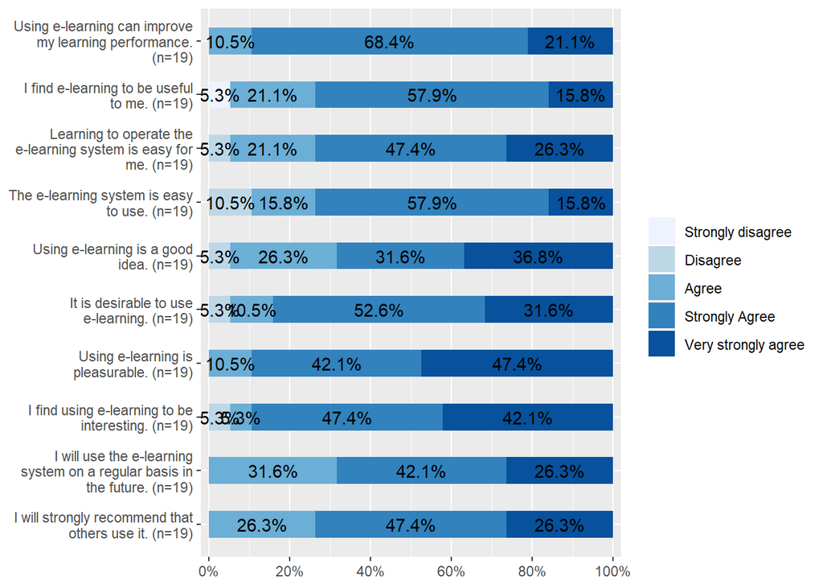

```r
generalSurveys = surveys %>% select("q1", "q2", "q3", "q4", "q5", "q6", "q7", "q8", "q9", "q10")
surveyMat = data.matrix(generalSurveys)
generalSurveys <- as.data.frame(surveyMat)
rating <- list("Strongly disagree", "Disagree", "Agree", "Strongly Agree", "Very strongly agree")
questions <- list("Using e-learning can improve my learning performance.", "I find e-learning to be useful to me.", "Learning to operate the e-learning system is easy for me.", "The e-learning system is easy to use.", "Using e-learning is a good idea.", "It is desirable to use e-learning.", "Using e-learning is pleasurable.", "I find using e-learning to be interesting.", "I will use the e-learning system on a regular basis in the future.", "I will strongly recommend that others use it.")
plot_stackfrq(generalSurveys, legend.labels = rating, axis.labels = rev(questions))
```

Despite being a likert of 6, ranging from “Very strongly disagree” to “Very strongly agree”, none of the participants opted for “Very strongly disagree” option, hence the stacked frequencies plot only shows 5 rating levels.

These questions are based from previous studies on e-learning continuance intention, concerning about perceived usefulness, perceived ease of use, attitude, perceived enjoyment, satisfaction and continuance intention. As seen from the plot, most participants show positive attitude towards the e-learning system. Very few have some negative feedbacks regarding the ease of use of e-learning platform, which can also affect their level of enjoyment when using the platform. Despite that, all participants are willing to continue using the platform in the future and agree that the platform is effective in improving learning performance.

## Stack Frequencies Plot of Opnions on Question Types in E-Learning Platform

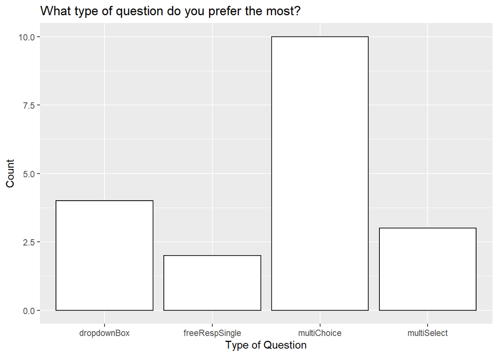

```r
qnTypeSurveys = surveys %>% select("q11", "q12", "q13", "q14", "q15", "q16", "q17", "q18", "q19", "q20")
ggplot(qnTypeSurveys, aes(x=q11)) + geom_histogram(colour="black", fill="white",  stat="count") + ggtitle("What type of question do you prefer the most?") + xlab("Type of Question") + ylab("Count")
```

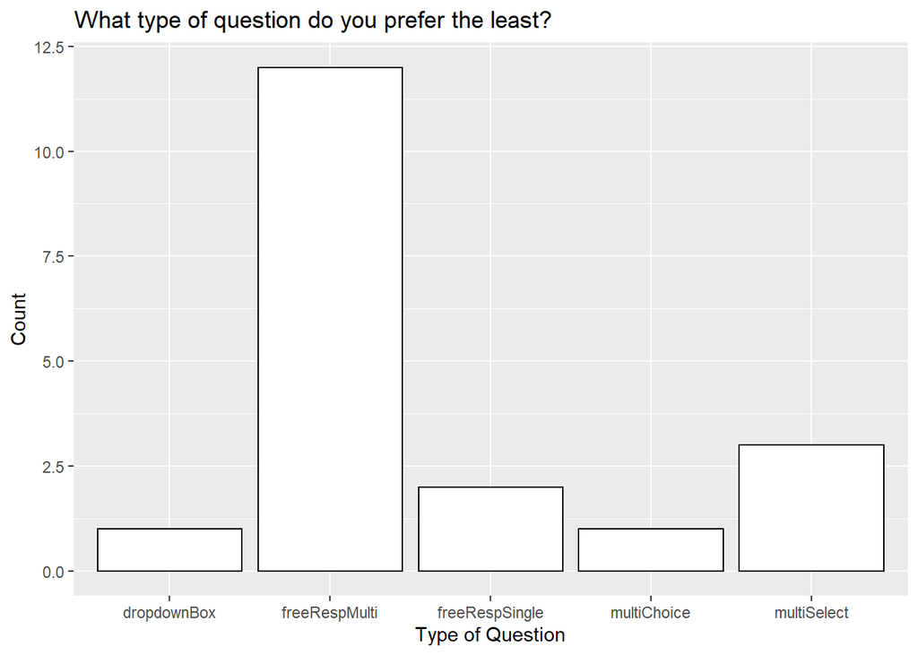

```r
ggplot(qnTypeSurveys, aes(x=q12)) + geom_histogram(colour="black", fill="white",  stat="count") + ggtitle("What type of question do you prefer the least?") + xlab("Type of Question") + ylab("Count")
```

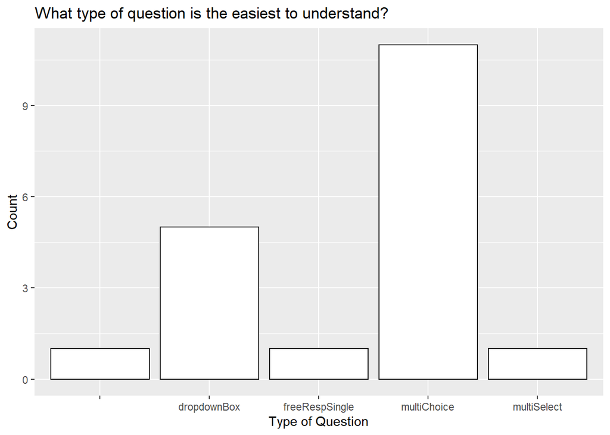

```r
ggplot(qnTypeSurveys, aes(x=q13)) + geom_histogram(colour="black", fill="white",  stat="count") + ggtitle("What type of question is the easiest to understand?") + xlab("Type of Question") + ylab("Count")
```

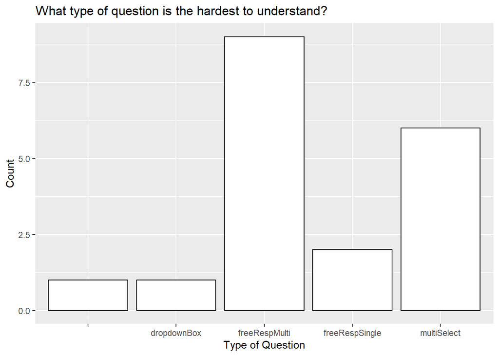

```r
ggplot(qnTypeSurveys, aes(x=q14)) + geom_histogram(colour="black", fill="white",  stat="count") + ggtitle("What type of question is the hardest to understand?") + xlab("Type of Question") + ylab("Count")
```

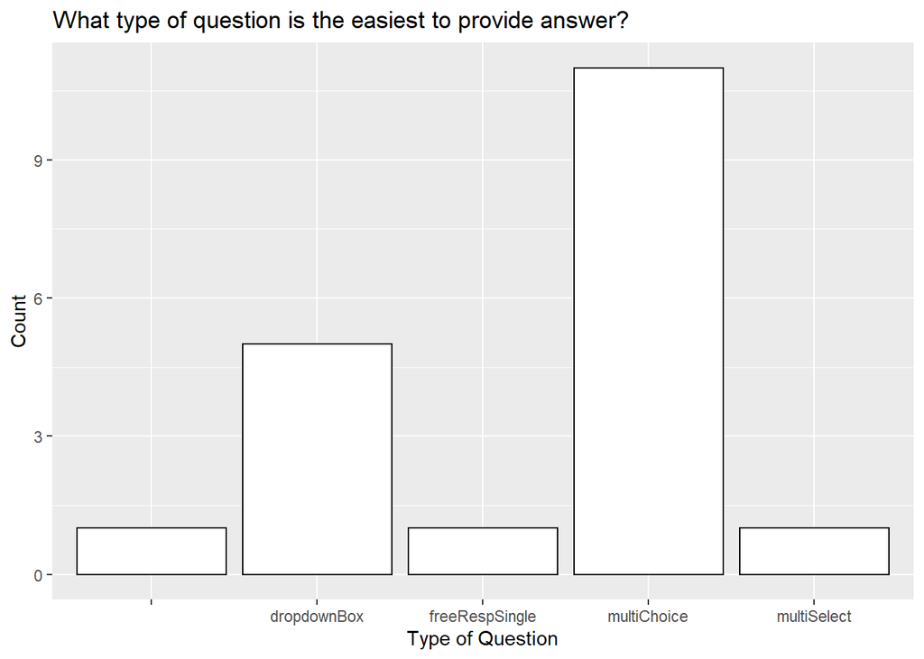

```r
ggplot(qnTypeSurveys, aes(x=q15)) + geom_histogram(colour="black", fill="white",  stat="count") + ggtitle("What type of question is the easiest to provide answer?") + xlab("Type of Question") + ylab("Count")
```

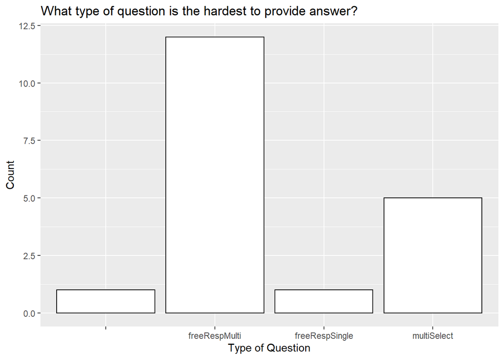

```r
ggplot(qnTypeSurveys, aes(x=q16)) + geom_histogram(colour="black", fill="white",  stat="count") + ggtitle("What type of question is the hardest to provide answer?") + xlab("Type of Question") + ylab("Count")
```

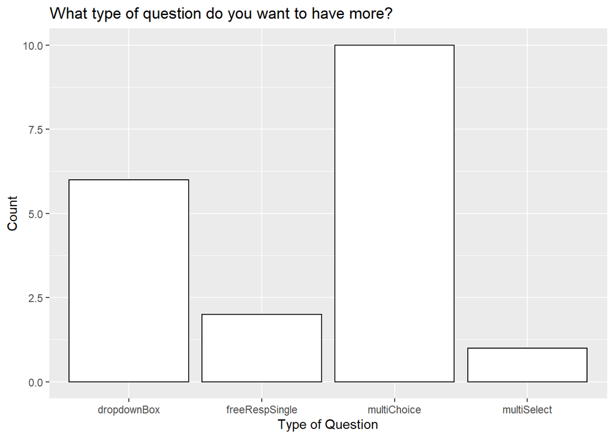

```r
ggplot(qnTypeSurveys, aes(x=q17)) + geom_histogram(colour="black", fill="white",  stat="count") + ggtitle("What type of question do you want to have more?") + xlab("Type of Question") + ylab("Count")
```

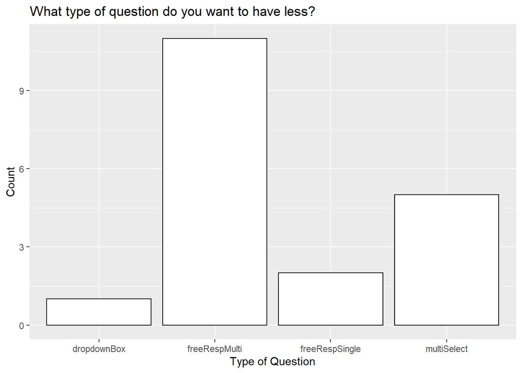

```r
ggplot(qnTypeSurveys, aes(x=q18)) + geom_histogram(colour="black", fill="white",  stat="count") + ggtitle("What type of question do you want to have less?") + xlab("Type of Question") + ylab("Count")
```

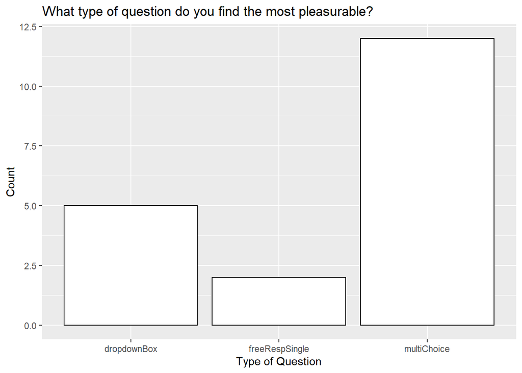

```r
ggplot(qnTypeSurveys, aes(x=q19)) + geom_histogram(colour="black", fill="white",  stat="count") + ggtitle("What type of question do you find the most pleasurable?") + xlab("Type of Question") + ylab("Count")
```

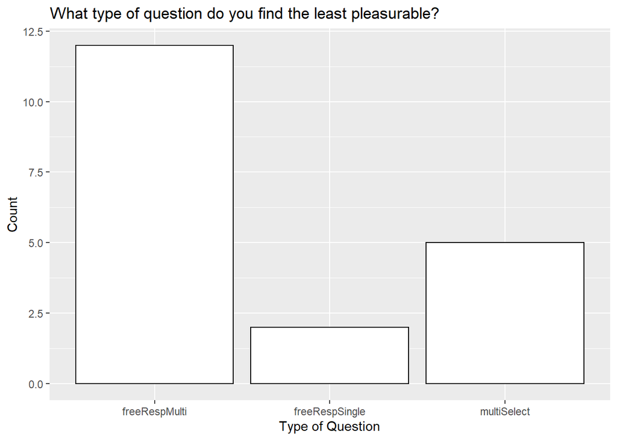

```r
ggplot(qnTypeSurveys, aes(x=q20)) + geom_histogram(colour="black", fill="white",  stat="count") + ggtitle("What type of question do you find the least pleasurable?") + xlab("Type of Question") + ylab("Count")
```

The next part of the survey focuses on the effectiveness of each type of question. Some of the plots have a “blank” bar, indicating that participants did not answer that particular question. These questions are built to concern about user’s preference, with each catogery having both extremes to give a big picture of opinions towards question types. Looking at the plots, we can see that participants show positive feedbacks towards mainly Multiple Choice and Dropdown Box with Multiple Choice being the top choice. Meanwhile, Free Response with multiple answers and Multiple Select are less favored, with the former being the bottom choice in term of preference, ease to understand and answer, pleasurability, and continuance intention. This results are within the expectation and reflect well with the performance from the quizzes.

## Demographic of Participants

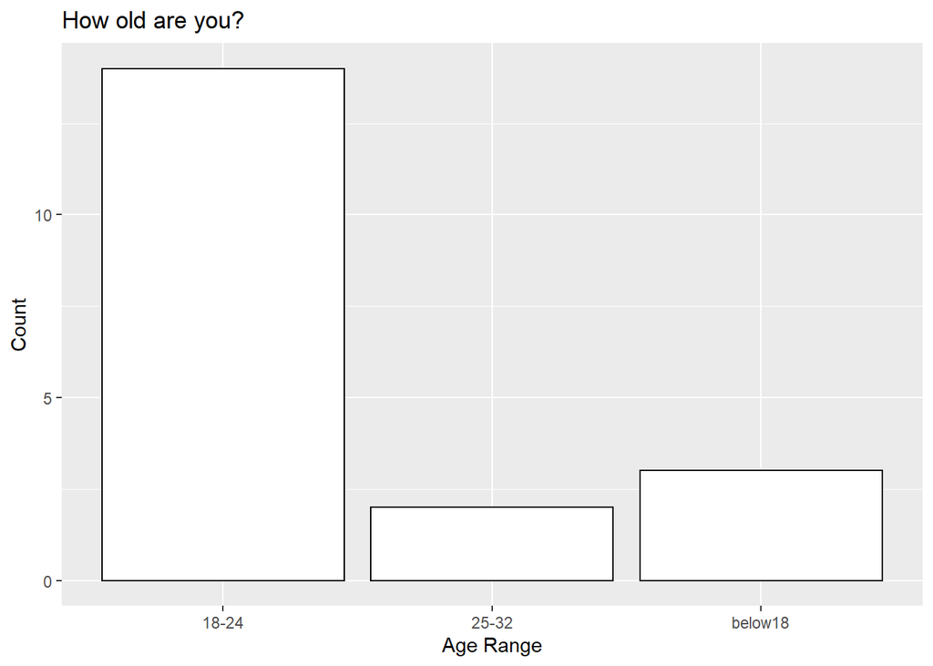

```r
ggplot(surveys, aes(x=q21)) + geom_histogram(colour="black", fill="white",  stat="count", ) + ggtitle("How old are you?") + xlab("Age Range") + ylab("Count")
```

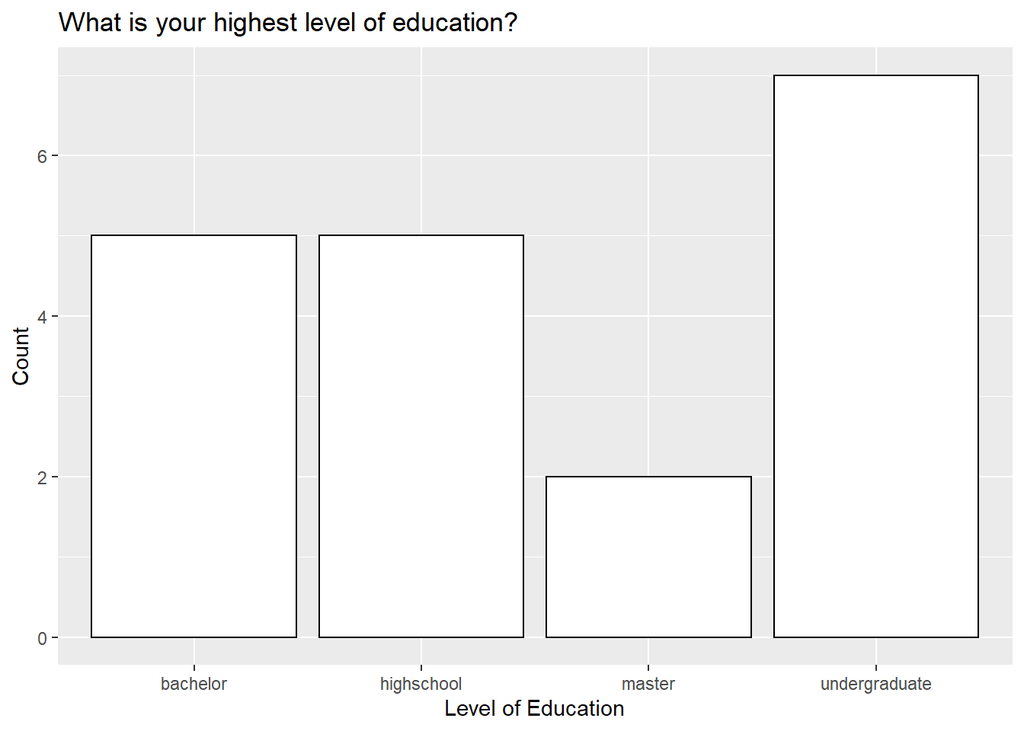

```r
ggplot(surveys, aes(x=q22)) + geom_histogram(colour="black", fill="white",  stat="count", ) + ggtitle("What is your highest level of education? ") + xlab("Level of Education") + ylab("Count")
```

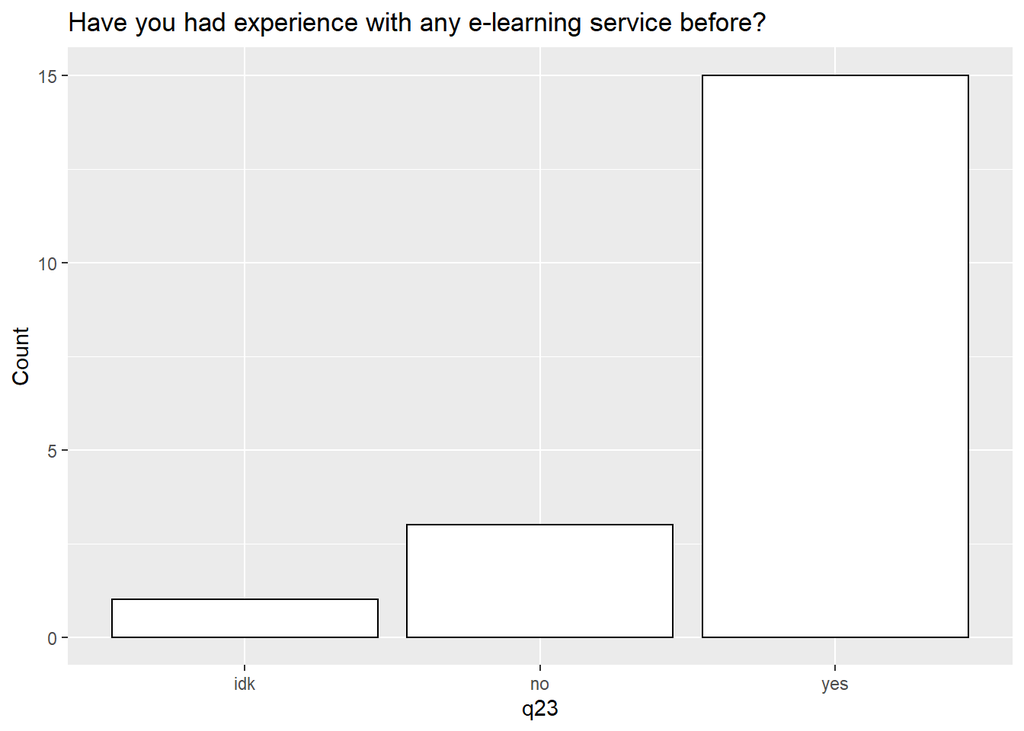

```r
ggplot(surveys, aes(x=q23)) + geom_histogram(colour="black", fill="white",  stat="count", ) + ggtitle("Have you had experience with any e-learning service before?") + ylab("Count")
```

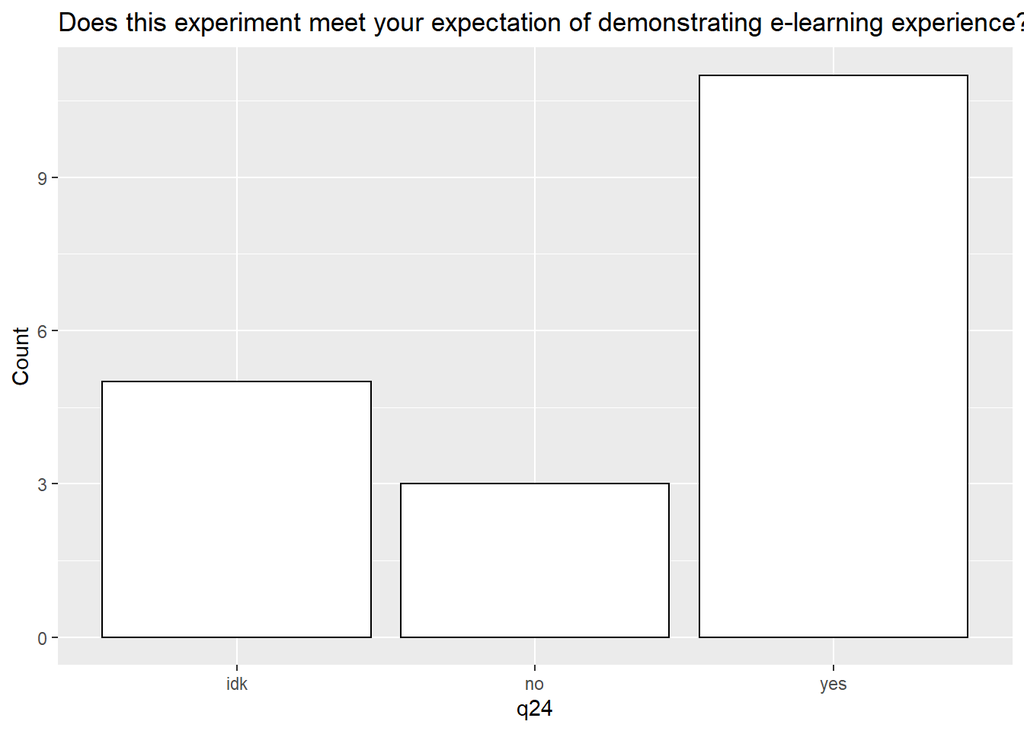

```r
ggplot(surveys, aes(x=q24)) + geom_histogram(colour="black", fill="white",  stat="count", ) + ggtitle("Does this experiment meet your expectation of demonstrating e-learning experience?") + ylab("Count")
```

Because there are different e-learning platform available nowadays, and our trial e-learning experiment cannot reflect exactly on different formats of other e-learning platforms, some participants are unsure whether the experiment matches with their own e-learning experience.